# The Fiscal Health Measurement Model, Tax Year 2023

Fitting, scoring, and validating three directional dimensions and one context dimension

## Purpose

`dimension-discovery-2023.Rmd` found four stable dimensions in the 2023 full-990 filers. Three have a clear healthy direction; one describes the business model. This document **freezes** that structure into a reusable measurement model:

| Dimension | Indicators | Healthy direction |
| --- | --- | --- |
| **Leverage** | debt/assets, payables share of short-term capital | lower |
| **Performance & growth** | surplus margin, return on assets, net-asset, revenue, and asset growth | higher |
| **Liquidity & reserves** | months of cash, liquid months, assets/revenue, current ratio | higher |
| **Asset structure** (context) | cash share vs. land & buildings share | none |

The composite fiscal health index averages the three directional dimensions. Asset structure and the standalone ratios (self-sufficiency, admin share, fundraising share) are scored and reported, but they get no weight.

**Key ideas**

- **A fitted model is a set of stored parameters.** It records percentile bounds, transformation constants, centers and scales, indicator directions, and dimension coefficients. Scoring new data reuses them; nothing is re-estimated.
- **Orientation:** before averaging, every indicator in a dimension is flipped so that higher means healthier. For the context dimension, higher simply means a more liquid asset base.
- **Standardized-mean scoring:** a dimension score is the average of its oriented z-scores, rescaled to mean 0 and SD 1. It is transparent, and here it is nearly identical to PCA or factor-weighted scores.
- **Context vs. health:** a stable dimension without a healthy direction is scored and reported, but it has zero weight in the composite.
- **Holdout check:** fit the model on half the organizations and score the other half. The scores should match the full-sample fit.
- **Peer-group percentile:** an organization’s rank among similar organizations (same subsector and size band) rather than among all filers. A hospital at its peers’ median is typical for a hospital, even if hospitals as a group score low nationally.

```r
library(dplyr)
library(knitr)
library(psych)
if (file.exists(file.path(params$pkg_dir, "DESCRIPTION"))) {
  pkgload::load_all(params$pkg_dir, quiet = TRUE)
} else {
  library(fiscal)
}
source("build-ratio-frame.R")
set.seed(params$seed)
fmt <- function(x, d = 2) format(round(x, d), nsmall = d, big.mark = ",")
pct <- function(x, d = 1) paste0(format(round(100 * x, d), nsmall = d), "%")
```

## 1. Ratio frame

The frame is built exactly as in the dimension-discovery document: rule-based reformulations, conditional imputation, and growth measured within the 2023 return, with blanks filled from 2022.

```r
# The BMF-merged extract carries NTEE classifications for peer groups (Section 8).
cache_file <- file.path(params$data_dir, c("efile-2023-bmf-dedup.rds", "efile-2023.rds"))
cache_file <- cache_file[file.exists(cache_file)][1]
if (is.na(cache_file)) stop("No cached 2023 e-file extract; render fiscal-health-index-2023.Rmd first.")
efile <- readRDS(cache_file)
if (!"nteev2_subsector" %in% names(efile)) {
  efile <- panel990::bmf_merge(efile, verbose = FALSE)   # attach NTEE and subsection
}
classification <- as.data.frame(efile)[efile$RETURN_TYPE == "990",
  intersect(c("EIN2", "nteev2_subsector", "ntee_code_major_group", "subsection_code",
              "ntee_code_clean", "F9_00_EXEMPT_STAT_501C3_X"), names(efile))]
prior_file <- file.path(params$data_dir, "efile-2022-p01p10-dedup.rds")
if (!file.exists(prior_file)) stop("Render dimension-discovery-2023.Rmd first to cache the 2022 tables.")
prior <- as.data.frame(readRDS(prior_file))[, c("EIN2", "F9_01_REV_TOT_CY")]

built <- build_ratio_frame(efile, seed = params$seed, growth = TRUE, prior = prior)
rm(efile, prior); invisible(gc())

k <- built$components
frame <- built$frame
ids <- data.frame(EIN2 = built$ein, stringsAsFactors = FALSE)
data.frame(organizations = format(nrow(frame), big.mark = ","))
```

| organizations |
| --- |
| 321,612 |

## 2. Model specification

```r
dimensions <- list(
  leverage           = c("debt_assets", "payables_una"),
  performance_growth = c("surplus_margin", "return_assets", "na_growth", "rev_growth", "asset_growth"),
  reserves           = c("months_cash", "liquid_months", "assets_rev", "current"),
  asset_structure    = c("cash_assets", "land_assets"))
standalone <- c("self_suff", "admin_exp", "fundr_exp")

directions <- c(
  debt_assets = "lower", payables_una = "lower",
  surplus_margin = "higher", return_assets = "higher", na_growth = "higher",
  rev_growth = "higher", asset_growth = "higher",
  months_cash = "higher", liquid_months = "higher", assets_rev = "higher", current = "higher",
  cash_assets = "higher", land_assets = "lower",
  self_suff = "context", admin_exp = "context", fundr_exp = "context")

registry <- fiscal_metrics()
reg_dir <- setNames(registry$direction, registry$metric)
kable(data.frame(
  indicator = names(directions),
  dimension = c(rep(names(dimensions), lengths(dimensions)), rep("standalone", length(standalone))),
  direction = unname(directions),
  package_registry = unname(reg_dir[names(directions)])),
  row.names = FALSE)
```

| indicator | dimension | direction | package_registry |
| --- | --- | --- | --- |
| debt_assets | leverage | lower | lower |
| payables_una | leverage | lower |  |
| surplus_margin | performance_growth | higher | higher |
| return_assets | performance_growth | higher | higher |
| na_growth | performance_growth | higher |  |
| rev_growth | performance_growth | higher |  |
| asset_growth | performance_growth | higher |  |
| months_cash | reserves | higher |  |
| liquid_months | reserves | higher |  |
| assets_rev | reserves | higher | lower |
| current | reserves | higher | higher |
| cash_assets | asset_structure | higher | higher |
| land_assets | asset_structure | lower |  |
| self_suff | standalone | context | higher |
| admin_exp | standalone | context |  |
| fundr_exp | standalone | context |  |

> **Decision 1: Set every direction explicitly.**

> Several indicators are not in the package registry (`payables_una`, the growth rates, the bounded and symmetric reformulations). Two differ from it on purpose:
> - **`assets_rev` is *higher*, not *lower*.** The registry reads assets per dollar of revenue as asset *inefficiency*. Empirically it loads with months of cash and liquid reserves: organizations with more assets per dollar of activity have more resources relative to operations. Oriented *lower*, it would cancel the other reserve indicators.
> - **The asset-structure dimension is oriented, even though it has no healthy direction.** Cash share and land share load with opposite signs. Leaving both unoriented would make them cancel. Orienting cash *higher* and land *lower* defines the score as “more liquid, less fixed asset base”. That describes the business model and says nothing about health.

> The three standalone ratios stay `context`, i.e. unoriented. The fit records a warning for them, and that is intended.

### 2.1 Freeze the normalization

```r
vars <- c(unlist(dimensions, use.names = FALSE), standalone)
norm_spec <- fit_winsor_normalize(frame[vars], p = 0.01)
X <- apply_winsor_normalize(frame[vars], norm_spec)
stopifnot(isTRUE(all.equal(X, as.data.frame(lapply(frame[vars], winsor_normalize)),
                           check.attributes = FALSE)))
kable(norm_spec, digits = 3, row.names = FALSE,
      caption = "Stored normalization parameters (1st/99th percentile winsorizing)")
```

Stored normalization parameters (1st/99th percentile winsorizing)

| variable | lo | hi | skew_winsorized | type | scale_s | anchor | mean | sd |
| --- | --- | --- | --- | --- | --- | --- | --- | --- |
| debt_assets | 0.000 | 3.687 | 4.227 | asinh_right | 0.124 | 3.687 | 0.816 | 1.025 |
| payables_una | 0.000 | 1.000 | 3.035 | asinh_right | 0.040 | 1.000 | 0.738 | 1.136 |
| surplus_margin | -0.994 | 0.925 | -0.171 | none |  | 0.925 | 0.053 | 0.312 |
| return_assets | -3.605 | 1.000 | -4.058 | asinh_left | 0.981 | 1.000 | -0.875 | 0.284 |
| na_growth | -2.000 | 2.000 | 0.116 | none |  | 2.000 | 0.076 | 0.578 |
| rev_growth | -1.822 | 2.000 | 0.251 | none |  | 2.000 | 0.104 | 0.558 |
| asset_growth | -1.789 | 2.000 | 0.677 | none |  | 2.000 | 0.085 | 0.491 |
| months_cash | 0.000 | 429.514 | 5.867 | asinh_right | 6.955 | 429.514 | 1.096 | 0.960 |
| liquid_months | -67.313 | 961.431 | 5.664 | asinh_right | 8.864 | 961.431 | 1.047 | 1.312 |
| assets_rev | 0.000 | 75.185 | 4.845 | asinh_right | 1.389 | 75.185 | 1.179 | 1.026 |
| current | 0.103 | 18987.155 | 6.623 | asinh_right | 23.359 | 18987.155 | 1.513 | 1.652 |
| cash_assets | 0.000 | 1.000 | 0.191 | none |  | 1.000 | 0.486 | 0.378 |
| land_assets | 0.000 | 0.977 | 1.147 | asinh_right | 0.313 | 0.977 | 0.508 | 0.655 |
| self_suff | 0.000 | 1.626 | 0.816 | none |  | 1.626 | 0.371 | 0.439 |
| admin_exp | 0.000 | 1.000 | 2.356 | asinh_right | 0.130 | 1.000 | 0.829 | 0.708 |
| fundr_exp | 0.000 | 0.302 | 3.201 | asinh_right | 0.040 | 0.302 | 0.351 | 0.652 |

`fit_winsor_normalize()` stores each ratio’s winsorizing bounds, whether an asinh step is applied (and on which tail), the asinh scale, and the final mean and standard deviation. `apply_winsor_normalize()` reproduces the discovery-stage frame exactly (the `stopifnot()` check above), and can put another year’s ratios on the 2023 scale.

## 3. Fit

```r
fits <- lapply(c(standardized_mean = "standardized_mean", pca = "pca", factor = "factor"),
               function(method) fiscal_health_fit(X, dimensions = dimensions,
                                                  standalone = standalone, scoring = method,
                                                  indicator_direction = directions,
                                                  missing = "median"))
fit <- fits$standardized_mean
fit
```

```
## Fitted fiscal-health measurement model
##   Dimensions: 4
##   Standalone indicators: 3
##   Reference observations: 321612
##   Missing-value rule: median
##   Direction warnings: 1
```

```r
fit$warnings
```

```
## [1] "Direction is context-dependent or unknown for: self_suff, admin_exp, fundr_exp. They are left unoriented; supply `indicator_direction` to override."
```

### 3.1 Scoring method

```r
score_only <- function(f) fiscal_health_score(X, f, append = FALSE, include_standalone = FALSE,
                                              include_coverage = FALSE)
s <- lapply(fits, score_only)
kable(data.frame(
  dimension = names(dimensions),
  r_mean_vs_pca    = sapply(names(dimensions), function(d) cor(s$standardized_mean[[paste0("fh_", d)]], s$pca[[paste0("fh_", d)]])),
  r_mean_vs_factor = sapply(names(dimensions), function(d) cor(s$standardized_mean[[paste0("fh_", d)]], s$factor[[paste0("fh_", d)]]))),
  digits = 3, row.names = FALSE)
```

| dimension | r_mean_vs_pca | r_mean_vs_factor |
| --- | --- | --- |
| leverage | 1.000 | 1.000 |
| performance_growth | 0.997 | 0.975 |
| reserves | 0.999 | 0.970 |
| asset_structure | 1.000 | 1.000 |

```r
coef_table <- do.call(rbind, lapply(names(dimensions), function(d) data.frame(
  dimension = d, indicator = dimensions[[d]],
  standardized_mean = fits$standardized_mean$dimensions[[d]]$coefficients,
  pca    = fits$pca$dimensions[[d]]$coefficients,
  factor = fits$factor$dimensions[[d]]$coefficients)))
kable(coef_table, digits = 3, row.names = FALSE,
      caption = "Indicator coefficients by scoring method (PCA and factor coefficients are unit-length)")
```

Indicator coefficients by scoring method (PCA and factor coefficients are unit-length)

| dimension | indicator | standardized_mean | pca | factor |
| --- | --- | --- | --- | --- |
| leverage | debt_assets | 0.50 | 0.707 | 0.707 |
| leverage | payables_una | 0.50 | 0.707 | 0.707 |
| performance_growth | surplus_margin | 0.20 | 0.413 | 0.211 |
| performance_growth | return_assets | 0.20 | 0.498 | 0.655 |
| performance_growth | na_growth | 0.20 | 0.493 | 0.538 |
| performance_growth | rev_growth | 0.20 | 0.319 | 0.142 |
| performance_growth | asset_growth | 0.20 | 0.487 | 0.466 |
| reserves | months_cash | 0.25 | 0.556 | 0.778 |
| reserves | liquid_months | 0.25 | 0.542 | 0.581 |
| reserves | assets_rev | 0.25 | 0.464 | 0.201 |
| reserves | current | 0.25 | 0.426 | 0.133 |
| asset_structure | cash_assets | 0.50 | 0.707 | 0.707 |
| asset_structure | land_assets | 0.50 | 0.707 | 0.707 |

> **Decision 2: Score dimensions as standardized means.**

> *Why:* The standardized mean correlates at least 0.97 with factor-weighted scores and 1.00 with PCA-weighted scores.

> Factor weights would concentrate performance & growth on return on assets and net-asset growth, and reserves on months of cash. That makes the scores depend on a single year’s estimates. Equal weights are transparent and don’t change between reference years.

> Equal weighting does give balance-sheet growth (net-asset and asset growth) two of the five performance indicators. The comparison above shows that choice changes scores very little.

### 3.2 Reliability

```r
reliability <- do.call(rbind, lapply(names(dimensions), function(d) {
  spec <- fit$dimensions[[d]]
  Z <- sweep(as.matrix(X[spec$indicators]), 2, spec$indicator_multiplier, "*")
  a <- suppressWarnings(psych::alpha(Z, check.keys = FALSE, warnings = FALSE))
  data.frame(dimension = d, indicator = spec$indicators,
             item_rest_r = a$item.stats$r.drop,
             alpha_if_dropped = a$alpha.drop$raw_alpha,
             dimension_alpha = a$total$raw_alpha)
}))
kable(reliability, digits = 3, row.names = FALSE)
```

| dimension | indicator | item_rest_r | alpha_if_dropped | dimension_alpha |
| --- | --- | --- | --- | --- |
| leverage | debt_assets | 0.676 | 0.676 | 0.807 |
| leverage | payables_una | 0.676 | 0.676 | 0.807 |
| performance_growth | surplus_margin | 0.597 | 0.827 | 0.844 |
| performance_growth | return_assets | 0.766 | 0.780 | 0.844 |
| performance_growth | na_growth | 0.746 | 0.786 | 0.844 |
| performance_growth | rev_growth | 0.429 | 0.869 | 0.844 |
| performance_growth | asset_growth | 0.736 | 0.789 | 0.844 |
| reserves | months_cash | 0.686 | 0.632 | 0.760 |
| reserves | liquid_months | 0.647 | 0.655 | 0.760 |
| reserves | assets_rev | 0.485 | 0.743 | 0.760 |
| reserves | current | 0.432 | 0.770 | 0.760 |
| asset_structure | cash_assets | 0.512 | 0.512 | 0.677 |
| asset_structure | land_assets | 0.512 | 0.512 | 0.677 |

Every indicator correlates positively with the rest of its dimension once oriented, so the directions in Section 2 are internally consistent. The dimension alphas are acceptable to good for short, formative accounting scales. Where dropping an indicator would raise alpha, the gain is small, and the indicator was kept because of its loading and its substantive role.

## 4. Score, weight, and index

```r
weights <- fiscal_weights(fit,
  weights = c(leverage = 1, performance_growth = 1, reserves = 1, asset_structure = 0),
  include_standalone = FALSE, min_coverage = 0.5,
  name = "Equal weights on the three directional dimensions")
weights
```

```
## Fiscal-health weights
##   Name: Equal weights on the three directional dimensions
##   Method: custom
##   Measures: 4
##   Missing-score rule: reweight
##             measure measure_type original_weight    weight
##            leverage    dimension               1 0.3333333
##  performance_growth    dimension               1 0.3333333
##            reserves    dimension               1 0.3333333
##     asset_structure    dimension               0 0.0000000
```

```r
scored  <- fiscal_health_score(X, fit)
indexed <- fiscal_health_index(scored, weights)
indexed$fiscal_health_pctile <- dplyr::ntile(indexed$fiscal_health, 100)

score_cols <- c("fh_leverage", "fh_performance_growth", "fh_reserves", "fh_asset_structure", "fiscal_health")
```

> **Decision 3: Weight the composite 1/3 each on leverage, performance & growth, and reserves; give asset structure zero weight.**

> *Why:* No outcome in a single cross-section can calibrate weights, so equal weights are the defensible default. Zero weight for asset structure follows from its lack of a healthy direction. Scoring it anyway keeps it available as a stratifier or control.

> **Note on the sign of leverage:** `fh_leverage` is oriented, so *higher means less leveraged*. All three weighted scores read “higher is healthier”.

## 5. Results

### 5.1 Distributions and correlations

```r
kable(t(sapply(indexed[score_cols], function(v)
  c(mean = mean(v, na.rm = TRUE), sd = sd(v, na.rm = TRUE),
    quantile(v, c(.05, .25, .5, .75, .95), na.rm = TRUE)))), digits = 2)
```

|  | mean | sd | 5% | 25% | 50% | 75% | 95% |
| --- | --- | --- | --- | --- | --- | --- | --- |
| fh_leverage | 0 | 1.00 | -2.33 | -0.51 | 0.46 | 0.79 | 0.79 |
| fh_performance_growth | 0 | 1.00 | -1.58 | -0.40 | -0.04 | 0.37 | 1.70 |
| fh_reserves | 0 | 1.00 | -1.19 | -0.74 | -0.23 | 0.51 | 1.98 |
| fh_asset_structure | 0 | 1.00 | -1.73 | -0.79 | -0.03 | 1.07 | 1.23 |
| fiscal_health | 0 | 0.71 | -1.23 | -0.42 | 0.03 | 0.44 | 1.11 |

```r
kable(round(cor(indexed[score_cols]), 2), caption = "Score correlations")
```

Score correlations

|  | fh_leverage | fh_performance_growth | fh_reserves | fh_asset_structure | fiscal_health |
| --- | --- | --- | --- | --- | --- |
| fh_leverage | 1.00 | 0.14 | 0.43 | 0.23 | 0.74 |
| fh_performance_growth | 0.14 | 1.00 | 0.17 | 0.07 | 0.62 |
| fh_reserves | 0.43 | 0.17 | 1.00 | 0.09 | 0.76 |
| fh_asset_structure | 0.23 | 0.07 | 0.09 | 1.00 | 0.18 |
| fiscal_health | 0.74 | 0.62 | 0.76 | 0.18 | 1.00 |

The leverage score has a **ceiling**. Its 75th and 95th percentiles are equal because organizations with no liabilities and no payables all get the best possible value (28.3% of filers). That tie is real, not a measurement artifact: having no debt is the least-leveraged state.

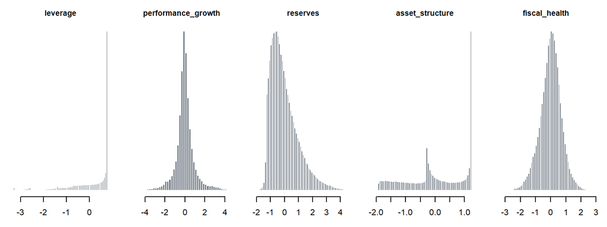

```r
op <- par(mfrow = c(1, 5), mar = c(3, 1, 2.5, 1), cex.main = 0.9)
for (v in score_cols) hist(indexed[[v]], breaks = 60, col = "#6d7681", border = "white",
                           main = sub("^fh_", "", v), yaxt = "n", xlab = "", ylab = "")
```

```r
par(op)
```

### 5.2 Face validity: raw financial conditions by index quintile

These conditions are computed from the raw 2023 figures. Several of them feed the index, so the check is partly circular. What it tests is whether orientation, transformation, and weighting behave as intended on recognizable distress signals.

```r
validity <- data.frame(
  quintile             = dplyr::ntile(indexed$fiscal_health, 5),
  deficit              = k$R < k$E,
  negative_net_assets  = k$NA_eoy < 0,
  negative_liquid      = frame$liquid_months < 0,
  under_1mo_cash       = frame$months_cash < 1,
  revenue_drop_20      = frame$rev_growth < -0.2,
  liabilities_over_half = frame$debt_assets > 0.5,
  expenses             = k$E)
kable(validity |>
  group_by(quintile) |>
  summarise(n = format(n(), big.mark = ","),
            `deficit` = pct(mean(deficit)),
            `negative net assets` = pct(mean(negative_net_assets)),
            `negative liquid reserves` = pct(mean(negative_liquid)),
            `< 1 month cash` = pct(mean(under_1mo_cash)),
            `revenue down > 20%` = pct(mean(revenue_drop_20)),
            `liabilities > 50% of assets` = pct(mean(liabilities_over_half)),
            `median expenses ($)` = format(round(median(expenses)), big.mark = ",")),
  align = "r")
```

| quintile | n | deficit | negative net assets | negative liquid reserves | < 1 month cash | revenue down > 20% | liabilities > 50% of assets | median expenses ($) |
| --- | --- | --- | --- | --- | --- | --- | --- | --- |
| 1 | 64,323 | 70.9% | 23.9% | 33.6% | 25.3% | 20.8% | 53.1% | 1,090,873 |
| 2 | 64,323 | 51.5% | 1.2% | 8.9% | 11.2% | 16.5% | 14.0% | 877,187 |
| 3 | 64,322 | 39.7% | 0.2% | 3.2% | 7.2% | 15.7% | 4.7% | 495,802 |
| 4 | 64,322 | 25.2% | 0.1% | 1.5% | 4.4% | 15.6% | 2.2% | 322,006 |
| 5 | 64,322 | 12.7% | 0.0% | 0.8% | 3.5% | 13.7% | 1.1% | 139,302 |

What the table shows:

- **Balance-sheet distress** (negative net assets, negative liquid reserves, high debt) falls steeply from the bottom quintile to the top. It is heavily concentrated in the bottom fifth.
- **Deficits and thin cash** fall steadily as well.
- **Revenue drops of more than 20%** fall only modestly. Revenue growth has the lowest weight in practice, being one of five performance indicators with the weakest loading. A single year’s revenue decline is also a noisy distress signal on its own.
- **Size.** Median expenses fall sharply across quintiles. Small organizations more often carry no debt and hold reserves that are large relative to their spending, so they score higher. Treat the index as a measure of condition *relative to scale*, and compare within size groups where size matters (see 5.4).

### 5.3 Profiles across the three directional dimensions

```r
above <- function(v) ifelse(v >= median(v), "+", "-")
profile <- paste0("L", above(indexed$fh_leverage), " P", above(indexed$fh_performance_growth),
                  " R", above(indexed$fh_reserves))
kable(data.frame(profile = names(table(profile)),
                 share = as.numeric(prop.table(table(profile))),
                 median_index = as.numeric(tapply(indexed$fiscal_health, profile, median))) |>
        arrange(desc(median_index)),
      digits = 3, row.names = FALSE,
      caption = "L = low leverage, P = performance & growth, R = reserves; + above median, - below")
```

L = low leverage, P = performance & growth, R = reserves; + above median, - below

| profile | share | median_index |
| --- | --- | --- |
| L+ P+ R+ | 0.202 | 0.704 |
| L+ P- R+ | 0.142 | 0.301 |
| L+ P+ R- | 0.071 | 0.220 |
| L- P+ R+ | 0.086 | 0.195 |
| L- P- R+ | 0.070 | -0.109 |
| L+ P- R- | 0.085 | -0.195 |
| L- P+ R- | 0.141 | -0.298 |
| L- P- R- | 0.203 | -0.711 |

Organizations that are above the median on all three dimensions, or below on all three, account for more than chance would put there. That is expected, because the dimensions correlate positively. Still, most organizations have a *mixed* profile. The dimension scores carry information the composite hides; report them alongside it.

### 5.4 The index by size and asset structure

```r
size_group <- cut(k$E, c(0, 5e5, 5e6, Inf), labels = c("< $500k", "$500k-$5M", ">= $5M"), right = FALSE)
asset_q <- dplyr::ntile(indexed$fh_asset_structure, 4)
kable(indexed |>
        mutate(size = size_group) |>
        group_by(size) |>
        summarise(n = format(n(), big.mark = ","),
                  across(all_of(score_cols), ~ round(median(.x), 2))),
      caption = "Median scores by organization size (total expenses)")
```

Median scores by organization size (total expenses)

| size | n | fh_leverage | fh_performance_growth | fh_reserves | fh_asset_structure | fiscal_health |
| --- | --- | --- | --- | --- | --- | --- |
| < $500k | 171,273 | 0.77 | 0.00 | 0.09 | 0.31 | 0.26 |
| $500k-$5M | 111,728 | 0.05 | -0.07 | -0.40 | -0.08 | -0.12 |
| >= $5M | 38,611 | -0.75 | -0.06 | -0.64 | -0.38 | -0.45 |

```r
kable(indexed |>
        mutate(`asset structure quartile (1 = most fixed assets)` = asset_q) |>
        group_by(`asset structure quartile (1 = most fixed assets)`) |>
        summarise(across(all_of(c("fh_leverage", "fh_performance_growth", "fh_reserves", "fiscal_health")),
                         ~ round(median(.x), 2))),
      caption = "Median scores by asset-structure quartile (context dimension)")
```

Median scores by asset-structure quartile (context dimension)

| asset structure quartile (1 = most fixed assets) | fh_leverage | fh_performance_growth | fh_reserves | fiscal_health |
| --- | --- | --- | --- | --- |
| 1 | -0.07 | -0.13 | -0.42 | -0.17 |
| 2 | 0.49 | -0.02 | 0.03 | 0.12 |
| 3 | 0.22 | 0.00 | -0.27 | -0.02 |
| 4 | 0.79 | 0.05 | -0.18 | 0.21 |

These tables show why size and the context dimension are reported rather than ignored:

- **Size.** Scores fall with organization size, mostly through leverage and reserves. Performance & growth is nearly flat across size groups.
- **Asset structure.** The most property-heavy quartile has the lowest leverage scores (buildings are often mortgage-financed) and the lowest reserve scores (equity tied up in fixed assets isn’t liquid). The relationship isn’t strictly monotone across quartiles, but the most liquid asset bases score best on leverage.

Comparisons of health scores across very different business models should condition on asset structure and size, and on subsector once it is attached.

## 6. Reusing the model on new data

A fitted model should score organizations it never saw on the same scale as the reference sample. We fit the normalizer and the model on a random half of 2023 filers, score the other half, and compare against the full-sample model.

```r
half_a <- sample(nrow(frame), nrow(frame) / 2)
half_b <- setdiff(seq_len(nrow(frame)), half_a)
spec_a <- fit_winsor_normalize(frame[half_a, vars])
fit_a  <- fiscal_health_fit(apply_winsor_normalize(frame[half_a, vars], spec_a),
                            dimensions = dimensions, standalone = standalone,
                            indicator_direction = directions, missing = "median")
weights_a <- fiscal_weights(fit_a, weights = c(leverage = 1, performance_growth = 1, reserves = 1,
                                               asset_structure = 0),
                            include_standalone = FALSE, min_coverage = 0.5)
scored_b <- fiscal_health_index(
  fiscal_health_score(apply_winsor_normalize(frame[half_b, vars], spec_a), fit_a), weights_a)

kable(data.frame(
  score = score_cols,
  r_with_full_sample_model = sapply(score_cols, function(v) cor(scored_b[[v]], indexed[[v]][half_b])),
  holdout_mean = sapply(score_cols, function(v) mean(scored_b[[v]])),
  holdout_sd   = sapply(score_cols, function(v) sd(scored_b[[v]]))),
  digits = 4, row.names = FALSE)
```

| score | r_with_full_sample_model | holdout_mean | holdout_sd |
| --- | --- | --- | --- |
| fh_leverage | 1 | 0.0017 | 0.9997 |
| fh_performance_growth | 1 | 0.0022 | 0.9991 |
| fh_reserves | 1 | 0.0043 | 1.0024 |
| fh_asset_structure | 1 | 0.0046 | 0.9990 |
| fiscal_health | 1 | 0.0027 | 0.7053 |

Scores from the half-sample model are essentially identical to full-sample scores for the organizations it did not see. Their means and standard deviations match the reference scale. The stored parameters, not the scoring sample, define the scale.

To score another tax year:

1. Build its ratio frame with `build_ratio_frame()`.
2. Apply `norm_spec` with `apply_winsor_normalize()`.
3. Score with `fit`, then index with `weights`.

> **One caveat.** Conditional imputation is re-estimated within each year’s frame. Only the normalization and model parameters are frozen.

## 7. Comparison with the two-dimension index

```r
old_file <- file.path(params$data_dir, "fiscal-health-index-2023.rds")
has_old <- file.exists(old_file)
if (has_old) {
  old <- readRDS(old_file)$data
  m <- match(ids$EIN2, old$EIN2)
  both <- !is.na(m)
  print(kable(data.frame(
    comparison = c("Composite: 3-dimension vs. 2-dimension index",
                   "Reserves (new) vs. Reserves & Solvency (old)",
                   "Leverage (new, higher = less debt) vs. Reserves & Solvency (old)",
                   "Performance & growth (new) vs. Operating Performance (old)",
                   "Organizations in both"),
    value = c(fmt(c(cor(indexed$fiscal_health[both], old$fiscal_health[m[both]], use = "pair"),
                    cor(indexed$fh_reserves[both], old$fh_reserves_solvency[m[both]], use = "pair"),
                    cor(indexed$fh_leverage[both], old$fh_reserves_solvency[m[both]], use = "pair"),
                    cor(indexed$fh_performance_growth[both], old$fh_operating_performance[m[both]], use = "pair")), 3),
              format(sum(both), big.mark = ","))),
    row.names = FALSE, align = "lr"))
  q_new <- dplyr::ntile(indexed$fiscal_health[both], 5)
  q_old <- dplyr::ntile(old$fiscal_health[m[both]], 5)
  quintile_agreement <- table(new = q_new, old = q_old)
  same_quintile <- mean(q_new == q_old)
  moved_two_plus <- mean(abs(q_new - q_old) >= 2)
  print(kable(round(100 * prop.table(quintile_agreement, 1), 1),
              caption = "Old-index quintile (columns) by new-index quintile (rows), row percent"))

  # Among organizations that move two or more quintiles, which new dimension
  # differs most from its old counterpart?
  movers <- abs(q_new - q_old) >= 2
  gap <- abs(indexed$fh_leverage - indexed$fh_reserves)[both]
  gap_movers <- median(gap[movers]); gap_all <- median(gap)
  res_movers <- median(indexed$fh_reserves[both][movers]); res_all <- median(indexed$fh_reserves[both])
  print(kable(data.frame(
    group = c("Moved 2+ quintiles", "All matched organizations"),
    median_leverage = c(median(indexed$fh_leverage[both][movers]), median(indexed$fh_leverage[both])),
    median_performance_growth = c(median(indexed$fh_performance_growth[both][movers]),
                                  median(indexed$fh_performance_growth[both])),
    median_reserves = c(median(indexed$fh_reserves[both][movers]), median(indexed$fh_reserves[both])),
    median_abs_leverage_minus_reserves = c(
      median(abs(indexed$fh_leverage - indexed$fh_reserves)[both][movers]),
      median(abs(indexed$fh_leverage - indexed$fh_reserves)[both]))),
    digits = 2, row.names = FALSE))
} else {
  cat("Output of fiscal-health-index-2023.Rmd not found in data_dir; comparison skipped.\n")
}
```

Old-index quintile (columns) by new-index quintile (rows), row percent

| comparison | value |
| --- | --- |
| Composite: 3-dimension vs. 2-dimension index | 0.888 |
| Reserves (new) vs. Reserves & Solvency (old) | 0.844 |
| Leverage (new, higher = less debt) vs. Reserves & Solvency (old) | 0.714 |
| Performance & growth (new) vs. Operating Performance (old) | 0.854 |
| Organizations in both | 314,548 |

| 1 | 2 | 3 | 4 | 5 |
| --- | --- | --- | --- | --- |
| 70.8 | 23.4 | 5.5 | 0.3 | 0.0 |
| 24.4 | 41.4 | 27.3 | 6.6 | 0.2 |
| 4.0 | 27.5 | 39.0 | 28.0 | 1.6 |
| 0.7 | 6.8 | 22.4 | 47.7 | 22.4 |
| 0.1 | 0.9 | 5.8 | 17.3 | 75.8 |

| group | median_leverage | median_performance_growth | median_reserves | median_abs_leverage_minus_reserves |
| --- | --- | --- | --- | --- |
| Moved 2+ quintiles | 0.47 | -0.02 | 0.06 | 0.65 |
| All matched organizations | 0.43 | -0.03 | -0.22 | 0.65 |

The two indexes broadly agree on who is healthy: 55% of organizations fall in the same quintile, and 7% move two or more quintiles. The new model differs in three ways:

- **Leverage is its own dimension.** The old index folded debt into reserves.
- **Growth is part of performance.** Revenue, asset, and net-asset growth now count alongside margins.
- **Coverage.** Organizations with zero revenue or zero assets, previously dropped, are now scored through the rules and imputation.

The last table tests the obvious explanation for organizations that move two or more quintiles: a gap between leverage and reserve scores that the old reserves & solvency dimension averaged away. **The data don’t support it.** The median gap is 0.65 for movers and 0.65 for all organizations. Movers do have higher reserve scores (median 0.06 vs. -0.22). Rank changes reflect all the model changes together (new reserve and leverage definitions, growth in performance, and asinh rather than rank-normal scaling), not the leverage split alone.

## 8. Peer groups: subsector and size

National scores answer “how does this organization compare with all full-990 filers?” Section 5.4 showed that scores differ systematically by size and business model. A hospital, a food bank, and a business league run different balance sheets by design. **Peer-group percentiles** answer “how does this organization compare with organizations like it?”

### 8.1 Defining peers

```r
cls <- classification[match(ids$EIN2, classification$EIN2), ]
subsector_labels <- c(
  ART = "Arts & culture", EDU = "Education", UNI = "Higher education",
  ENV = "Environment & animals", HEL = "Health", HOS = "Hospitals",
  IFA = "International", PSB = "Public & societal benefit",
  MMB = "Mutual & membership benefit", REL = "Religion", HMS = "Human services")
subsection_labels <- c(
  `3` = "Unclassified 501(c)(3)", `4` = "Social welfare 501(c)(4)",
  `5` = "Labor & agricultural 501(c)(5)", `6` = "Business leagues 501(c)(6)",
  `7` = "Social clubs 501(c)(7)", `8` = "Fraternal 501(c)(8), (c)(10)",
  `10` = "Fraternal 501(c)(8), (c)(10)", `19` = "Veterans 501(c)(19)")

sub  <- as.character(cls$nteev2_subsector)
code <- as.character(cls$subsection_code)
c3   <- cls$F9_00_EXEMPT_STAT_501C3_X %in% "X"
peer_sector <- ifelse(sub %in% names(subsector_labels), subsector_labels[sub],
               ifelse(code %in% names(subsection_labels), subsection_labels[code],
               ifelse(c3 | code %in% "3", "Unclassified 501(c)(3)", "Unclassified, other exempt")))

# Subsectors that span several NTEE major groups are split into those groups
# (first letter of the NTEE code). Education, arts, religion, international, and
# membership benefit are each a single major group; hospitals and higher
# education are already their own subsectors.
split_subsectors <- c("HMS", "PSB", "HEL", "ENV")
major_group_labels <- c(
  C = "environment", D = "animal-related",
  E = "health care", F = "mental health & crisis intervention",
  G = "diseases & medical disciplines", H = "medical research",
  I = "crime & legal", J = "employment", K = "food, agriculture & nutrition",
  L = "housing & shelter", M = "public safety & relief", N = "recreation & sports",
  O = "youth development", P = "multipurpose & other",
  R = "civil rights & advocacy", S = "community improvement",
  T = "philanthropy & grantmaking", U = "science & technology",
  V = "social science", W = "public & societal benefit, other")
# Major groups that belong to each split subsector. A code outside its
# subsector's range (rare BMF inconsistencies) goes to the subsector's
# catch-all group instead of forming a one-organization sector.
expected_letters <- list(HMS = LETTERS[9:16], PSB = LETTERS[18:23], HEL = LETTERS[5:8], ENV = c("C", "D"))
catch_all <- c(HMS = "P", PSB = "W", HEL = "E", ENV = "C")
peer_sector_pooled <- peer_sector          # subsector-level sector, before splitting
is_split <- sub %in% split_subsectors
major_letter <- substr(as.character(cls$ntee_code_clean), 1, 1)
in_range <- mapply(function(l, s) l %in% expected_letters[[s]],
                   major_letter[is_split], sub[is_split])
peer_sector[is_split] <- paste0(
  subsector_labels[sub[is_split]], ": ",
  major_group_labels[ifelse(in_range, major_letter[is_split], catch_all[sub[is_split]])])

peer_source <- ifelse(is_split, "NTEE v2 subsector, split by NTEE major group",
               ifelse(sub %in% names(subsector_labels), "NTEE v2 subsector",
               ifelse(is.na(sub), "no BMF match: subsection / 501(c)(3) flag",
                      "NTEE unclassified: IRS subsection")))
size_band <- cut(k$E, c(0, 5e5, 5e6, Inf), right = FALSE,
                 labels = c("< $500k", "$500k-$5M", ">= $5M"))

kable(as.data.frame(table(`peer sector source` = peer_source)) |>
        mutate(share = round(Freq / sum(Freq), 3)), row.names = FALSE)
```

| peer.sector.source | Freq | share |
| --- | --- | --- |
| no BMF match: subsection / 501(c)(3) flag | 3254 | 0.010 |
| NTEE unclassified: IRS subsection | 97139 | 0.302 |
| NTEE v2 subsector | 73990 | 0.230 |
| NTEE v2 subsector, split by NTEE major group | 147229 | 0.458 |

> **Decision 4: Build peer sectors from NTEE v2 subsectors, with IRS subsection as the fallback for organizations the NTEE doesn’t classify.**

> *Why:*
> - **NTEE v2 subsectors** follow the NTEE major groups but split out hospitals and higher education. Their balance sheets differ from other health and education organizations enough to distort comparisons.
> - **Unclassified organizations are too many to ignore.** About 31% of full-990 filers have no usable NTEE code. More than half are not 501(c)(3)s, and for those the IRS subsection *is* the most meaningful classification: business leagues, social clubs, labor unions, and veterans’ posts each have a distinct financial model.
> - **Unclassified 501(c)(3)s** form their own peer sector rather than being pooled with classified charities.
> - **Subsectors that span several NTEE major groups are split into them.** These are human services (I–P), public & societal benefit (R–W), health (E–H), and environment & animals (C–D): together 147,229 filers. Within them, business models differ sharply:
>   - housing providers carry mortgaged property, while recreation leagues run small, cash-based operations;
>   - grantmaking foundations hold investment portfolios, while community development groups hold loans and real estate;
>   - clinics and medical-research organizations fund themselves very differently.

>   Section 8.3 checks whether each split changes anything.
> - **Single-major-group subsectors stay whole.** Education, arts, religion, international, and membership benefit each correspond to one NTEE major group, so there is nothing to split at this level.

```r
min_peer_n <- 250
cell <- paste(peer_sector, size_band, sep = " | ")
n_cell   <- ave(seq_along(cell), cell, FUN = length)
n_sector <- ave(seq_along(cell), peer_sector, FUN = length)
n_pooled <- ave(seq_along(cell), peer_sector_pooled, FUN = length)
# Fallback chain: sector x size -> sector (major group) -> whole subsector -> national.
peer_group <- ifelse(n_cell >= min_peer_n, cell,
              ifelse(n_sector >= min_peer_n, peer_sector,
              ifelse(n_pooled >= min_peer_n, peer_sector_pooled, "All full-990 filers")))
peer_level <- ifelse(n_cell >= min_peer_n, "sector x size",
              ifelse(n_sector >= min_peer_n, "sector only",
              ifelse(n_pooled >= min_peer_n, "whole subsector", "national")))

peer_table <- data.frame(peer_sector, size_band, peer_group) |>
  count(peer_sector, size_band, name = "n") |>
  tidyr::pivot_wider(names_from = size_band, values_from = n, values_fill = 0) |>
  mutate(total = rowSums(across(where(is.numeric)))) |>
  arrange(desc(total))
kable(peer_table, format.args = list(big.mark = ","),
      caption = "Organizations by peer sector and size band")
```

Organizations by peer sector and size band

| peer_sector | < $500k | $500k-$5M | >= $5M | total |
| --- | --- | --- | --- | --- |
| Unclassified 501(c)(3) | 21,562 | 15,981 | 6,262 | 43,805 |
| Human services: multipurpose & other | 13,847 | 12,513 | 4,521 | 30,881 |
| Education | 14,214 | 10,046 | 3,383 | 27,643 |
| Arts & culture | 11,895 | 6,623 | 1,191 | 19,709 |
| Public & societal benefit: community improvement | 8,386 | 5,287 | 1,063 | 14,736 |
| Business leagues 501(c)(6) | 6,750 | 6,012 | 1,154 | 13,916 |
| Human services: recreation & sports | 9,132 | 3,907 | 535 | 13,574 |
| Religion | 8,738 | 3,587 | 435 | 12,760 |
| Human services: housing & shelter | 6,197 | 5,020 | 1,193 | 12,410 |
| Unclassified, other exempt | 5,501 | 3,267 | 3,113 | 11,881 |
| Health: health care | 4,235 | 4,162 | 3,122 | 11,519 |
| Public & societal benefit: philanthropy & grantmaking | 6,201 | 3,334 | 1,128 | 10,663 |
| Labor & agricultural 501(c)(5) | 4,171 | 3,601 | 717 | 8,489 |
| Social clubs 501(c)(7) | 3,884 | 2,261 | 806 | 6,951 |
| Social welfare 501(c)(4) | 4,780 | 1,553 | 307 | 6,640 |
| Environment & animals: animal-related | 4,165 | 2,144 | 330 | 6,639 |
| Human services: youth development | 3,477 | 2,541 | 406 | 6,424 |
| Environment & animals: environment | 3,112 | 2,544 | 488 | 6,144 |
| International | 2,951 | 2,143 | 656 | 5,750 |
| Human services: public safety & relief | 4,105 | 1,159 | 100 | 5,364 |
| Fraternal 501(c)(8), (c)(10) | 4,480 | 707 | 64 | 5,251 |
| Health: mental health & crisis intervention | 2,251 | 2,058 | 933 | 5,242 |
| Public & societal benefit: public & societal benefit, other | 2,444 | 1,318 | 558 | 4,320 |
| Human services: employment | 1,379 | 1,570 | 711 | 3,660 |
| Human services: food, agriculture & nutrition | 1,858 | 1,348 | 393 | 3,599 |
| Human services: crime & legal | 1,603 | 1,584 | 378 | 3,565 |
| Veterans 501(c)(19) | 3,166 | 285 | 9 | 3,460 |
| Mutual & membership benefit | 1,944 | 843 | 652 | 3,439 |
| Hospitals | 469 | 443 | 2,087 | 2,999 |
| Health: diseases & medical disciplines | 1,507 | 1,029 | 343 | 2,879 |
| Public & societal benefit: civil rights & advocacy | 1,075 | 1,107 | 223 | 2,405 |
| Higher education | 321 | 512 | 857 | 1,690 |
| Health: medical research | 780 | 548 | 197 | 1,525 |
| Public & societal benefit: science & technology | 499 | 486 | 227 | 1,212 |
| Public & societal benefit: social science | 194 | 205 | 69 | 468 |

```r
kable(as.data.frame(table(peer_level)) |> mutate(share = round(Freq / sum(Freq), 4)),
      row.names = FALSE, caption = paste("Peer-group level used (minimum", min_peer_n, "per group)"))
```

Peer-group level used (minimum 250 per group)

| peer_level | Freq | share |
| --- | --- | --- |
| sector only | 1288 | 0.004 |
| sector x size | 320324 | 0.996 |

```r
c(peer_groups = length(unique(peer_group)))
```

```
## peer_groups
##         103
```

```r
# Percentile of each organization within its peer group's *reference set*. For
# a sector x size cell, the reference set is the cell. For a fallback group
# (small cell), it is every organization in the whole sector or subsector, not
# just the members of the small cell. Ties get the average rank.
reference_percentile <- function(x, group, reference_rows) {
  out <- numeric(length(x))
  for (g in unique(group)) {
    target <- which(group == g)
    v <- sort(x[reference_rows(g)])
    below    <- findInterval(x[target], v, left.open = TRUE)   # count < x
    at_below <- findInterval(x[target], v)                     # count <= x
    out[target] <- pmax(1, ceiling(100 * ((below + at_below + 1) / 2) / length(v)))
  }
  out
}
peer_reference <- function(g) {
  if (g == "All full-990 filers") return(seq_along(peer_group))
  which(cell == g | peer_sector == g | peer_sector_pooled == g)
}
```

> **Decision 5: Peer group = sector × size band, with at least 250 organizations.**

> Size is part of the peer definition because Section 5.4 showed scores fall steadily with size, through leverage and reserves. Three bands match the size groups used throughout: under $500k, $500k–$5M, and $5M+ in total expenses. Cells below 250 fall back to the whole sector. A major group below 250 falls back further, to its whole subsector. Percentiles are never computed from tiny groups.

### 8.2 How much do sector and size matter?

```r
r2 <- function(y, ...) summary(lm(y ~ ., data = data.frame(...)))$r.squared
kable(data.frame(
  score = score_cols,
  size_band = sapply(score_cols, function(v) r2(indexed[[v]], size_band)),
  peer_sector = sapply(score_cols, function(v) r2(indexed[[v]], peer_sector)),
  sector_plus_size = sapply(score_cols, function(v) r2(indexed[[v]], peer_sector, size_band)),
  peer_group = sapply(score_cols, function(v) r2(indexed[[v]], peer_group))),
  digits = 3, row.names = FALSE,
  caption = "Share of variance (R-squared) explained by peer definitions")
```

Share of variance (R-squared) explained by peer definitions

| score | size_band | peer_sector | sector_plus_size | peer_group |
| --- | --- | --- | --- | --- |
| fh_leverage | 0.146 | 0.070 | 0.194 | 0.202 |
| fh_performance_growth | 0.004 | 0.003 | 0.007 | 0.008 |
| fh_reserves | 0.101 | 0.044 | 0.139 | 0.148 |
| fh_asset_structure | 0.046 | 0.091 | 0.136 | 0.145 |
| fiscal_health | 0.127 | 0.040 | 0.153 | 0.160 |

```r
sector_medians <- data.frame(peer_sector, indexed[score_cols],
                             national_pctile = indexed$fiscal_health_pctile) |>
  group_by(peer_sector) |>
  summarise(n = n(), across(all_of(c(score_cols, "national_pctile")), median)) |>
  arrange(desc(fiscal_health))
kable(sector_medians, digits = 2, format.args = list(big.mark = ","),
      caption = "Median scores and national percentile by peer sector")
```

Median scores and national percentile by peer sector

| peer_sector | n | fh_leverage | fh_performance_growth | fh_reserves | fh_asset_structure | fiscal_health | national_pctile |
| --- | --- | --- | --- | --- | --- | --- | --- |
| Human services: public safety & relief | 5,364 | 0.69 | 0.02 | 0.48 | -0.62 | 0.35 | 70 |
| Mutual & membership benefit | 3,439 | 0.78 | 0.04 | 0.42 | -0.18 | 0.33 | 70 |
| Public & societal benefit: philanthropy & grantmaking | 10,663 | 0.75 | 0.01 | 0.25 | 0.08 | 0.28 | 67 |
| Fraternal 501(c)(8), (c)(10) | 5,251 | 0.70 | -0.06 | 0.18 | -0.45 | 0.23 | 63 |
| Labor & agricultural 501(c)(5) | 8,489 | 0.75 | -0.03 | 0.09 | 0.37 | 0.23 | 63 |
| Veterans 501(c)(19) | 3,460 | 0.76 | -0.04 | 0.00 | -0.58 | 0.21 | 62 |
| Social welfare 501(c)(4) | 6,640 | 0.65 | -0.03 | 0.20 | 0.01 | 0.21 | 62 |
| Unclassified, other exempt | 11,881 | 0.48 | -0.02 | 0.28 | -0.24 | 0.14 | 57 |
| Environment & animals: environment | 6,144 | 0.51 | 0.05 | -0.12 | 0.19 | 0.13 | 57 |
| Environment & animals: animal-related | 6,639 | 0.70 | -0.01 | -0.26 | -0.04 | 0.12 | 56 |
| Religion | 12,760 | 0.74 | -0.02 | -0.31 | 0.14 | 0.09 | 54 |
| Human services: recreation & sports | 13,574 | 0.76 | 0.01 | -0.35 | 0.72 | 0.09 | 54 |
| Arts & culture | 19,709 | 0.51 | -0.06 | -0.19 | -0.07 | 0.07 | 53 |
| Health: medical research | 1,525 | 0.53 | -0.08 | -0.03 | 0.71 | 0.07 | 53 |
| Public & societal benefit: public & societal benefit, other | 4,320 | 0.43 | 0.01 | -0.09 | 0.27 | 0.05 | 52 |
| Health: diseases & medical disciplines | 2,879 | 0.50 | -0.03 | -0.18 | 0.58 | 0.05 | 52 |
| Human services: food, agriculture & nutrition | 3,599 | 0.60 | 0.00 | -0.37 | 0.08 | 0.05 | 51 |
| Education | 27,643 | 0.50 | 0.00 | -0.25 | 0.25 | 0.04 | 51 |
| Public & societal benefit: community improvement | 14,736 | 0.30 | -0.02 | -0.15 | 0.59 | 0.03 | 50 |
| Unclassified 501(c)(3) | 43,805 | 0.38 | -0.06 | -0.21 | -0.20 | 0.01 | 49 |
| Public & societal benefit: civil rights & advocacy | 2,405 | 0.34 | 0.04 | -0.28 | 0.91 | 0.01 | 49 |
| Human services: youth development | 6,424 | 0.52 | 0.00 | -0.40 | 0.36 | 0.01 | 49 |
| International | 5,750 | 0.69 | -0.10 | -0.40 | 0.86 | -0.01 | 48 |
| Business leagues 501(c)(6) | 13,916 | 0.18 | -0.05 | -0.21 | 0.52 | -0.03 | 46 |
| Public & societal benefit: science & technology | 1,212 | 0.20 | -0.01 | -0.24 | 0.39 | -0.04 | 46 |
| Human services: employment | 3,660 | 0.25 | -0.01 | -0.34 | 0.15 | -0.04 | 46 |
| Public & societal benefit: social science | 468 | 0.18 | -0.08 | -0.24 | 0.46 | -0.07 | 44 |
| Human services: crime & legal | 3,565 | 0.19 | 0.02 | -0.39 | 0.40 | -0.07 | 44 |
| Social clubs 501(c)(7) | 6,951 | 0.20 | -0.04 | -0.41 | -1.02 | -0.08 | 44 |
| Human services: multipurpose & other | 30,881 | 0.25 | -0.05 | -0.50 | -0.06 | -0.11 | 42 |
| Health: health care | 11,519 | 0.10 | -0.06 | -0.40 | -0.15 | -0.12 | 41 |
| Health: mental health & crisis intervention | 5,242 | -0.09 | -0.02 | -0.64 | 0.01 | -0.21 | 35 |
| Higher education | 1,690 | -0.27 | -0.07 | -0.44 | -0.45 | -0.25 | 33 |
| Human services: housing & shelter | 12,410 | -0.66 | -0.20 | -0.35 | -1.18 | -0.37 | 28 |
| Hospitals | 2,999 | -0.87 | -0.04 | -0.71 | -0.68 | -0.52 | 21 |

Peer groups explain 16% of the variance in the composite and 20% in leverage. Most of the variation in fiscal health is *within* peer groups, so the national scores remain meaningful.

Of the between-group differences, size band accounts for more than sector (13% vs. 4% of composite variance). Performance & growth is almost untouched by either. Peer adjustment mainly re-bases the balance-sheet dimensions, leverage and reserves.

The between-group differences are still systematic. Median national percentiles range from 21 (lowest peer sector) to 70 (highest). An organization in a low-scoring sector can look distressed nationally while being typical among its peers.

### 8.3 Splitting multi-major-group subsectors

Does splitting a subsector into its NTEE major groups produce better peers? If the major groups differ systematically, their members are being benchmarked against organizations with different financial models, and their percentiles will move when the split is made. Otherwise the split only adds groups.

```r
peer_cols <- c("fh_leverage", "fh_performance_growth", "fh_reserves", "fiscal_health")
split_idx <- which(is_split)
short <- function(x) sub("^[^:]+: ", "", x)
cap1  <- function(x) paste0(toupper(substr(x, 1, 1)), substring(x, 2))

# Peer percentiles with every subsector pooled (no major-group split) vs. split.
cell_pooled <- paste(peer_sector_pooled, size_band, sep = " | ")
n_cell_pooled <- ave(seq_along(cell_pooled), cell_pooled, FUN = length)
peer_group_pooled <- ifelse(n_cell_pooled >= min_peer_n, cell_pooled, peer_sector_pooled)
pooled_reference <- function(g) which(cell_pooled == g | peer_sector_pooled == g)
pooled_pct  <- reference_percentile(indexed$fiscal_health, peer_group_pooled, pooled_reference)
split_pct   <- reference_percentile(indexed$fiscal_health, peer_group, peer_reference)
split_shift <- split_pct - pooled_pct

by_subsector <- do.call(rbind, lapply(split_subsectors, function(s) {
  i <- which(sub %in% s)
  g <- factor(peer_sector[i])
  data.frame(
    subsector = subsector_labels[[s]], n = format(length(i), big.mark = ","),
    major_groups = sum(table(g) >= min_peer_n),
    r2_major_composite = r2(indexed$fiscal_health[i], g),
    r2_size_composite  = r2(indexed$fiscal_health[i], size_band[i]),
    r2_major_leverage  = r2(indexed$fh_leverage[i], g),
    r2_major_reserves  = r2(indexed$fh_reserves[i], g),
    rho_pooled_vs_split = cor(pooled_pct[i], split_pct[i], method = "spearman"),
    shift_10_plus = mean(abs(split_shift[i]) >= 10))
}))
kable(by_subsector, digits = 3, row.names = FALSE,
      caption = "By subsector: variance explained by major group (vs. size), and effect of the split on composite peer percentiles")
```

By subsector: variance explained by major group (vs. size), and effect of the split on composite peer percentiles

| subsector | n | major_groups | r2_major_composite | r2_size_composite | r2_major_leverage | r2_major_reserves | rho_pooled_vs_split | shift_10_plus |
| --- | --- | --- | --- | --- | --- | --- | --- | --- |
| Human services | 79,477 | 8 | 0.052 | 0.104 | 0.119 | 0.044 | 0.967 | 0.144 |
| Public & societal benefit | 33,804 | 6 | 0.020 | 0.094 | 0.029 | 0.025 | 0.978 | 0.096 |
| Health | 21,165 | 4 | 0.013 | 0.170 | 0.017 | 0.032 | 0.985 | 0.043 |
| Environment & animals | 12,783 | 2 | 0.000 | 0.082 | 0.020 | 0.009 | 0.991 | 0.000 |

```r
major_table <- data.frame(subsector = subsector_labels[sub[split_idx]],
                          major_group = short(peer_sector[split_idx]),
                          indexed[split_idx, peer_cols],
                          national_pctile = indexed$fiscal_health_pctile[split_idx],
                          shift = split_shift[split_idx]) |>
  group_by(subsector, major_group) |>
  summarise(n = n(),
            across(all_of(c(peer_cols, "national_pctile")), median),
            median_shift = median(shift),
            share_up_10 = mean(shift >= 10), share_down_10 = mean(shift <= -10),
            .groups = "drop") |>
  filter(n >= min_peer_n) |>
  arrange(subsector, desc(fiscal_health))
kable(major_table, digits = 2, format.args = list(big.mark = ","),
      caption = paste0("Major groups (n >= ", min_peer_n, "): median scores and composite peer-percentile shift (split minus pooled)"))
```

Major groups (n >= 250): median scores and composite peer-percentile shift (split minus pooled)

| subsector | major_group | n | fh_leverage | fh_performance_growth | fh_reserves | fiscal_health | national_pctile | median_shift | share_up_10 | share_down_10 |
| --- | --- | --- | --- | --- | --- | --- | --- | --- | --- | --- |
| Environment & animals | environment | 6,144 | 0.51 | 0.05 | -0.12 | 0.13 | 57 | 0 | 0.00 | 0.00 |
| Environment & animals | animal-related | 6,639 | 0.70 | -0.01 | -0.26 | 0.12 | 56 | 1 | 0.00 | 0.00 |
| Health | medical research | 1,525 | 0.53 | -0.08 | -0.03 | 0.07 | 53 | -5 | 0.00 | 0.11 |
| Health | diseases & medical disciplines | 2,879 | 0.50 | -0.03 | -0.18 | 0.05 | 52 | -3 | 0.00 | 0.00 |
| Health | health care | 11,519 | 0.10 | -0.06 | -0.40 | -0.12 | 41 | -1 | 0.00 | 0.00 |
| Health | mental health & crisis intervention | 5,242 | -0.09 | -0.02 | -0.64 | -0.21 | 35 | 6 | 0.14 | 0.00 |
| Human services | public safety & relief | 5,364 | 0.69 | 0.02 | 0.48 | 0.35 | 70 | -14 | 0.00 | 0.69 |
| Human services | recreation & sports | 13,574 | 0.76 | 0.01 | -0.35 | 0.09 | 54 | -2 | 0.00 | 0.02 |
| Human services | food, agriculture & nutrition | 3,599 | 0.60 | 0.00 | -0.37 | 0.05 | 51 | -5 | 0.00 | 0.07 |
| Human services | youth development | 6,424 | 0.52 | 0.00 | -0.40 | 0.01 | 49 | -1 | 0.00 | 0.04 |
| Human services | employment | 3,660 | 0.25 | -0.01 | -0.34 | -0.04 | 46 | -5 | 0.00 | 0.00 |
| Human services | crime & legal | 3,565 | 0.19 | 0.02 | -0.39 | -0.07 | 44 | -1 | 0.00 | 0.00 |
| Human services | multipurpose & other | 30,881 | 0.25 | -0.05 | -0.50 | -0.11 | 42 | 0 | 0.00 | 0.00 |
| Human services | housing & shelter | 12,410 | -0.66 | -0.20 | -0.35 | -0.37 | 28 | 11 | 0.55 | 0.00 |
| Public & societal benefit | philanthropy & grantmaking | 10,663 | 0.75 | 0.01 | 0.25 | 0.28 | 67 | -7 | 0.00 | 0.20 |
| Public & societal benefit | public & societal benefit, other | 4,320 | 0.43 | 0.01 | -0.09 | 0.05 | 52 | 1 | 0.01 | 0.00 |
| Public & societal benefit | community improvement | 14,736 | 0.30 | -0.02 | -0.15 | 0.03 | 50 | 4 | 0.05 | 0.00 |
| Public & societal benefit | civil rights & advocacy | 2,405 | 0.34 | 0.04 | -0.28 | 0.01 | 49 | 2 | 0.00 | 0.06 |
| Public & societal benefit | science & technology | 1,212 | 0.20 | -0.01 | -0.24 | -0.04 | 46 | -1 | 0.00 | 0.07 |
| Public & societal benefit | social science | 468 | 0.18 | -0.08 | -0.24 | -0.07 | 44 | 1 | 0.27 | 0.06 |

What the splits do:

- **Overall shift.** Across the 147,229 organizations in split subsectors, 10.6% move 10 or more percentile points and 2.6% move 20 or more.
- **Where the split matters most.** Major group matters most within human services, explaining 5% of composite variance there, and least within environment & animals (0%). In every split subsector, major group explains more of leverage than of the composite. The biggest differences between business models are in how they finance assets.
- **Splits that change little.** Environment & animals: fewer than 1% of organizations move 10+ points. Their major groups have nearly identical financial profiles, so the split is harmless but adds little.
- **Biggest movers.** Housing & shelter (human services) organizations gain the most once compared only with each other (median +11 points). Public safety & relief (human services) organizations lose the most (median -14). Under the pooled definitions, these groups looked weak or strong largely because of *which kind* of organization they are within their subsector.

> **Decision 6: Use NTEE major groups as peer sectors wherever a subsector spans more than one: human services, public & societal benefit, health, and environment & animals.**

> The splits move percentiles in consistent directions for whole major groups, not at random. Cells below 250 fall back first to the major group, then to the whole subsector: Health: medical research | >= $5M (197, sector only); Human services: public safety & relief | >= $5M (100, sector only); Public & societal benefit: civil rights & advocacy | >= $5M (223, sector only); Public & societal benefit: science & technology | >= $5M (227, sector only); Public & societal benefit: social science | $500k-$5M (205, sector only); Public & societal benefit: social science | < $500k (194, sector only); Public & societal benefit: social science | >= $5M (69, sector only).

### 8.4 Peer-group percentiles

```r
peer_cols <- c("fh_leverage", "fh_performance_growth", "fh_reserves", "fiscal_health")
peer_pct <- as.data.frame(lapply(indexed[peer_cols], reference_percentile,
                                 group = peer_group, reference_rows = peer_reference))
names(peer_pct) <- paste0(sub("^fh_", "", peer_cols), "_peer_pctile")
national_pct <- as.data.frame(lapply(indexed[peer_cols], reference_percentile,
                                     group = rep("all", nrow(indexed)),
                                     reference_rows = function(g) seq_len(nrow(indexed))))
names(national_pct) <- paste0(sub("^fh_", "", peer_cols), "_national_pctile")

shift <- peer_pct$fiscal_health_peer_pctile - national_pct$fiscal_health_national_pctile
kable(data.frame(
  check = c("Spearman rho, peer vs. national composite percentile",
            "Organizations shifting 20+ percentile points",
            "Organizations shifting 40+ percentile points",
            "Median absolute shift (points)"),
  value = c(fmt(cor(peer_pct$fiscal_health_peer_pctile, national_pct$fiscal_health_national_pctile,
                    method = "spearman"), 3),
            pct(mean(abs(shift) >= 20)), pct(mean(abs(shift) >= 40)),
            fmt(median(abs(shift)), 0))),
  row.names = FALSE, align = "lr")
```

| check | value |
| --- | --- |
| Spearman rho, peer vs. national composite percentile | 0.878 |
| Organizations shifting 20+ percentile points | 13.9% |
| Organizations shifting 40+ percentile points | 1.5% |
| Median absolute shift (points) | 10 |

```r
kable(data.frame(peer_sector, size_band, shift,
                 national = national_pct$fiscal_health_national_pctile) |>
        group_by(peer_sector) |>
        summarise(n = n(), median_national_pctile = median(national),
                  median_shift_to_peer = median(shift),
                  share_up_20 = mean(shift >= 20), share_down_20 = mean(shift <= -20)) |>
        arrange(median_shift_to_peer),
      digits = 2, format.args = list(big.mark = ","),
      caption = "Composite: shift from national to peer percentile, by sector")
```

Composite: shift from national to peer percentile, by sector

| peer_sector | n | median_national_pctile | median_shift_to_peer | share_up_20 | share_down_20 |
| --- | --- | --- | --- | --- | --- |
| Human services: public safety & relief | 5,364 | 70 | -17 | 0.00 | 0.44 |
| Fraternal 501(c)(8), (c)(10) | 5,251 | 63 | -13 | 0.00 | 0.06 |
| Social welfare 501(c)(4) | 6,640 | 62 | -11 | 0.03 | 0.21 |
| Veterans 501(c)(19) | 3,460 | 62 | -11 | 0.00 | 0.15 |
| Labor & agricultural 501(c)(5) | 8,489 | 63 | -10 | 0.00 | 0.21 |
| Mutual & membership benefit | 3,439 | 70 | -10 | 0.00 | 0.36 |
| Religion | 12,760 | 54 | -7 | 0.01 | 0.00 |
| Environment & animals: animal-related | 6,639 | 56 | -5 | 0.02 | 0.00 |
| Public & societal benefit: philanthropy & grantmaking | 10,663 | 67 | -5 | 0.00 | 0.28 |
| Unclassified, other exempt | 11,881 | 57 | -5 | 0.06 | 0.22 |
| Arts & culture | 19,709 | 53 | -4 | 0.02 | 0.00 |
| Human services: recreation & sports | 13,574 | 54 | -3 | 0.02 | 0.00 |
| Public & societal benefit: community improvement | 14,736 | 50 | -3 | 0.05 | 0.00 |
| Public & societal benefit: public & societal benefit, other | 4,320 | 52 | -3 | 0.05 | 0.00 |
| Environment & animals: environment | 6,144 | 57 | -1 | 0.03 | 0.20 |
| Health: diseases & medical disciplines | 2,879 | 52 | -1 | 0.07 | 0.01 |
| Health: medical research | 1,525 | 53 | -1 | 0.00 | 0.12 |
| Human services: food, agriculture & nutrition | 3,599 | 51 | -1 | 0.05 | 0.00 |
| Human services: youth development | 6,424 | 49 | -1 | 0.03 | 0.00 |
| Education | 27,643 | 51 | 0 | 0.06 | 0.00 |
| International | 5,750 | 48 | 0 | 0.06 | 0.00 |
| Unclassified 501(c)(3) | 43,805 | 49 | 0 | 0.09 | 0.10 |
| Business leagues 501(c)(6) | 13,916 | 46 | 1 | 0.05 | 0.00 |
| Public & societal benefit: civil rights & advocacy | 2,405 | 49 | 1 | 0.00 | 0.00 |
| Social clubs 501(c)(7) | 6,951 | 44 | 1 | 0.20 | 0.00 |
| Higher education | 1,690 | 33 | 2 | 0.30 | 0.00 |
| Human services: crime & legal | 3,565 | 44 | 2 | 0.07 | 0.00 |
| Human services: multipurpose & other | 30,881 | 42 | 2 | 0.10 | 0.00 |
| Human services: employment | 3,660 | 46 | 3 | 0.11 | 0.00 |
| Public & societal benefit: science & technology | 1,212 | 46 | 3 | 0.00 | 0.11 |
| Health: mental health & crisis intervention | 5,242 | 35 | 4 | 0.24 | 0.00 |
| Public & societal benefit: social science | 468 | 44 | 4 | 0.00 | 0.00 |
| Health: health care | 11,519 | 41 | 6 | 0.18 | 0.00 |
| Human services: housing & shelter | 12,410 | 28 | 16 | 0.39 | 0.00 |
| Hospitals | 2,999 | 21 | 18 | 0.48 | 0.07 |

```r
example_sectors <- c("Hospitals", "Human services: housing & shelter", "Human services: recreation & sports",
                     "Business leagues 501(c)(6)")
ex <- data.frame(peer_group, national = national_pct$fiscal_health_national_pctile,
                 peer = peer_pct$fiscal_health_peer_pctile, sector = peer_sector) |>
  filter(sector %in% example_sectors, peer == 50) |>
  group_by(peer_group) |>
  summarise(`national percentile of a peer-median organization` = round(median(national)))
kable(ex, caption = "Where a typical (50th peer percentile) organization sits nationally")
```

Where a typical (50th peer percentile) organization sits nationally

| peer_group | national percentile of a peer-median organization |
| --- | --- |
| Business leagues 501(c)(6) \| $500k-$5M | 39 |
| Business leagues 501(c)(6) \| < $500k | 57 |
| Business leagues 501(c)(6) \| >= $5M | 24 |
| Hospitals \| $500k-$5M | 48 |
| Hospitals \| < $500k | 78 |
| Hospitals \| >= $5M | 16 |
| Human services: housing & shelter \| $500k-$5M | 25 |
| Human services: housing & shelter \| < $500k | 32 |
| Human services: housing & shelter \| >= $5M | 20 |
| Human services: recreation & sports \| $500k-$5M | 41 |
| Human services: recreation & sports \| < $500k | 60 |
| Human services: recreation & sports \| >= $5M | 29 |

How to read peer percentiles:

- **Peer percentile 50** means typical *for that peer group*. The last table shows how different “typical” is across groups in national terms.
- **Use national scores** to measure sector-wide conditions or to compare groups. **Use peer percentiles** to judge one organization, set benchmarks, or flag outliers within a field.
- **Use both for screening.** A low peer percentile flags organizations that are weak *even by their sector’s norms*. A low national percentile with a typical peer percentile says the weakness comes from the sector’s financial model. Report both.

### 8.5 Storing peer norms for new data

Percentiles for a later year, or for a single organization, should be read off the 2023 reference distributions rather than re-ranked within the new data. We store the 1st–99th percentile cut points of each score in each peer group.

```r
peer_norms <- do.call(rbind, lapply(unique(peer_group), function(g) {
  rows <- peer_reference(g)   # full reference set, including for fallback groups
  do.call(rbind, lapply(peer_cols, function(v) data.frame(
    peer_group = g, score = v, n = length(rows), percentile = 1:99,
    cut = quantile(indexed[[v]][rows], (1:99) / 100, names = FALSE))))
}))

lookup_peer_percentile <- function(score_value, score_name, group, norms) {
  vapply(seq_along(score_value), function(i) {
    cuts <- norms$cut[norms$peer_group == group[i] & norms$score == score_name]
    as.numeric(findInterval(score_value[i], cuts) + 1)
  }, numeric(1))
}
check_rows <- sample(nrow(indexed), 2000)
looked_up <- lookup_peer_percentile(indexed$fiscal_health[check_rows], "fiscal_health",
                                    peer_group[check_rows], peer_norms)
c(norm_rows = nrow(peer_norms),
  r_lookup_vs_ranked = round(cor(looked_up, peer_pct$fiscal_health_peer_pctile[check_rows]), 4),
  max_abs_difference = max(abs(looked_up - peer_pct$fiscal_health_peer_pctile[check_rows])))
```

```
##          norm_rows r_lookup_vs_ranked max_abs_difference
##              40788                  1                  1
```

The stored cut points reproduce the ranked peer percentiles to within one point. The difference comes from how ties and percentile boundaries are handled. Scoring a new organization then takes three steps: score it with the fitted model, assign it a peer group, and look up its percentile.

## 9. Saved model

```r
model <- list(
  normalization = norm_spec,
  dimensions = dimensions,
  standalone = standalone,
  directions = directions,
  fit = fit,
  weights = weights,
  peers = list(definition = "NTEE v2 subsector (split by NTEE major group where a subsector spans several; IRS subsection fallback) x expense band",
               subsector_labels = subsector_labels, subsection_labels = subsection_labels,
               split_subsectors = split_subsectors, major_group_labels = major_group_labels,
               size_breaks = c(0, 5e5, 5e6, Inf), min_n = min_peer_n, norms = peer_norms),
  scores = cbind(ids, peer_sector = peer_sector, size_band = size_band,
                 peer_group = peer_group, peer_level = peer_level,
                 indexed[, c(score_cols, paste0("fh_", standalone), "fiscal_health_coverage")],
                 national_pct, peer_pct),
  reference = list(tax_year = 2023, n = nrow(frame), built = Sys.time()))
model_file <- file.path(params$data_dir, "fiscal-health-model-2023.rds")
saveRDS(model, model_file)
data.frame(saved = normalizePath(model_file, winslash = "/"),
           size_mb = round(file.size(model_file) / 1e6, 1))
```

| saved | size_mb |
| --- | --- |
| C:/Users/jlecy/AppData/Local/R/cache/R/fiscal/efile/fiscal-health-model-2023.rds | 32.4 |

## 10. Limitations and next steps

- **Validity beyond face validity.** The quintile checks use conditions that partly feed the index. The decisive test is predictive: do low 2023 scores precede deficits, declining net assets, or stopping filing in 2024–2025? That needs later tax years.
- **Weights.** Equal weights are a default, not an estimate. Once outcomes are available, weights can be calibrated (for example, to predict insolvency) and passed to `fiscal_weights()`.
- **Finer peers.** Every subsector that spans several NTEE major groups is now split. The remaining large peer sectors can’t be split at the major-group level:
  - **Education** (one major group, B) could be split by NTEE division, e.g. elementary & secondary schools (B20s) vs. student and educational services (B80s–B90s).
  - **Unclassified 501(c)(3)s** have no NTEE code at all. The IRS public-charity (foundation) code would separate schools, churches, hospitals, and supporting organizations hidden in that group.
  - **Arts and religion** are single major groups, and more homogeneous.
- **NTEE coverage.** Close to a third of full-990 filers are unclassified in the BMF. Classifying them from mission text or program descriptions would move unclassified 501(c)(3)s into real subsectors.
- **Package port.** `build-ratio-frame.R` (rules, imputation, growth) and `fit_winsor_normalize()` / `apply_winsor_normalize()` belong in the package, so the model can be refit and applied without the dev scripts.